# Multivariate Analysis

Eduardo Hidalgo

2019

# Summary

- Introduction
  - Linear algebra and basic statistics
  - Data examples
- Principal Component Analysis (PCA)
- Correspondence Analysis
- Data Clustering
- Exercises Review

## Introduction

A dataset is a matrix where each row is interpreted as a single observation (object, person, individual or temporal unit) and each column is interpreted as an observed variable. For example:

$$\begin{pmatrix}
x_{1}^{1}& \cdot & \cdot & \cdot & \cdot & \cdot & \cdot & \cdot & \cdot & x_{1}^{m}\\
\cdot & & x_{2}^{2} & & & & & & & \cdot \\
\cdot& & & \cdot & & & & & & \cdot \\
\cdot& & & & & \cdot & & & & \cdot \\
\cdot& & & & & & & \cdot & & \cdot \\
x_{n}^{1}& \cdot & \cdot & \cdot & \cdot & \cdot & \cdot & \cdot & \cdot & x_{n}^{m}
\end{pmatrix}_{(n,m)}$$

Each observation (row in the matrix) can be treated as a vector of dimension $m$. And each variable (column in the matrix) can be treated as a vector of dimension $n$. Hence:

$$observation_{i}=\begin{pmatrix}
x_{i}^{1}\\
\cdot\\
\cdot\\
\cdot\\
x_{i}^{m}\\
\end{pmatrix}_{(m \times 1)} \textit{ with } i \in [1,n] \textit{ and } variable_{j}=\begin{pmatrix}
x_{1}^{j}\\
\cdot\\
\cdot\\
\cdot\\
x_{n}^{j}\\
\end{pmatrix}_{(n \times 1)} \textit{ with } j \in [1,m]$$

|  | Energy (kcal) | Protein (g) | Lipid (g) | Calcium (mg) | Iron (mg) |
| --- | --- | --- | --- | --- | --- |
| Oliveoil | 900 | 0 | 100 | 0.1 | 0.05 |
| Butter | 770 | 0 | 85 | 13 | 0.2 |
| Whiting | 85 | 19 | 1 | 25 | 0.9 |
| Beef | 208 | 18 | 15 | 12 | 1.5 |
| Chicken | 158 | 20 | 8.5 | 18 | 1.8 |
| Milk | 57 | 3 | 3 | 126 | 0.1 |
| Yogurt | 59 | 3.2 | 3.2 | 125 | 0.2 |
| Flamingcheese | 316 | 26 | 23.2 | 800 | 0.8 |
| Serra cheese | 392 | 26 | 32 | 800 | 1.2 |
| Rice | 350 | 7.5 | 0.5 | 10 | 0.5 |

[output cut: 10 more lines]

And

$$\textit{food type}_{i}=\begin{pmatrix}
\textit{Energy (kcal)}\\
\textit{Protein (g)}\\
\textit{Lipid (g)}\\
\textit{Calcium (mg)}\\
\textit{Iron (mg)}\\
\end{pmatrix}_{(5 \times 1)} \textit{ with } i \in [1,20] \textit{ and } variable_{j}=\begin{pmatrix}
\textit{Oliveoil}\\
\textit{Butter}\\
\cdot\\
\cdot\\
\textit{Cabbage}\\
\end{pmatrix}_{(20 \times 1)} \textit{ with } j \in [1,5]$$

## Linear algebra and basic statistics

### Definitions

#### Dfn I: Inner-product

The *Inner-product* of two vectors with same dimensions $x,y \in \mathbb{R}^{n}$ is an **escalar** (or single number) and is defined as:
$$<x,y>=\sum_{i=1}^{n} x_{i}y_{i}$$

Note that the *Inner-product* of a vector $x \in \mathbb{R}^{n}$ with that same vector is equal to the power two of the vector:
$$<x,x>=\sum_{i=1}^{n} x_{i}^{2}=\left \| x \right \|^{2}$$

#### Dfn II: Perpendicular vectors

Two vectors with same dimensions $x,y \in \mathbb{R}^{n}$ are said to be *perpendicular* and denoted $x \perp y$ *iff*:

$$<x,y>=0$$

Note that $n$ *perpendicular* vectors can generate a $\textit{n-dimensional space}$, for example the $\textit{2-dimensional space}$ can be constructed by the following rule:

$$a_{1}(1,0)+a_{2}(0,1) \textit{ with } a_{1},a_{2}\in \mathbb{R}^{2}$$

By convention we denote the vectors $e_{1}^{t} \equiv (1,0,..,0), e_{2}^{t} \equiv (0,1,...,0),..., e_{n}^{t} \equiv (0,0,..,1) \in \mathbb{R}^n$ (note that the $n^{th}$ denotes the position of the single $1$).

#### Dfn III: Identity Matrix

The *identity matrix* is a *square matrix* and *diagonal matrix* such that each of the elements in the diagonal is equal to $1$:
$$\mathbf{I}_{(n,n)}=\begin{pmatrix}
1& \cdot & \cdot & \cdot & \cdot & \cdot & \cdot & \cdot & \cdot &0\\
\cdot & 1 & & & & & & & & \cdot \\
\cdot& & & \cdot & & & & & & \cdot \\
\cdot& & & & & \cdot & & & & \cdot \\
\cdot& & & & & & & \cdot & & \cdot \\
0& \cdot & \cdot & \cdot & \cdot & \cdot & \cdot & \cdot & \cdot & 1
\end{pmatrix}_{(n,n)}=(e_{1},e_{2},...,e_{n})$$

Note that it is always possible to express the a vector $x \in \mathbb{R}^{n}$ as the product of himself with the *identity matrix*:

$$(x_{1},...,x_{n})_{(1 \times n)} \times \begin{pmatrix}
1& \cdot & \cdot & \cdot & \cdot & \cdot & \cdot & \cdot & \cdot &0\\
\cdot & 1 & & & & & & & & \cdot \\
\cdot& & & \cdot & & & & & & \cdot \\
\cdot& & & & & \cdot & & & & \cdot \\
\cdot& & & & & & & \cdot & & \cdot \\
0& \cdot & \cdot & \cdot & \cdot & \cdot & \cdot & \cdot & \cdot & 1
\end{pmatrix}_{(n,n)}=(x_{1}I_{1,1},x_{2}I_{2,2},...,x_{n}I_{n,n})_{(1 \times n)}=(x_{1},...,x_{n})_{(1 \times n)}$$

And so the *inner-product with metric* $\mathbf{I}$ of two vectors $x,y \in \mathbb{R}^{n}$ can be written as:
$$<x,y>_{I}=x^{t} \mathbf{I}y=<x,y>$$

#### Dfn III: Euclidean distance

The *euclidean distance* between two vectors $x,y \in \mathbb{R}^{n}$ is an **escalar** (or single number) and is defined as:
$$d(x,y)=\left \| x-y \right \|_{I}=\sqrt{(x-y)^{t} \mathbf{I}(x-y)}=\sqrt{<x-y,x-y>_{ I}}=\sqrt{(x_{1}-y_{1})^{2}+(x_{2}-y_{2})^{2}+\cdot \cdot \cdot +(x_{n}-y_{n})^{2}}$$
Note that the distance can be treated either as a *inner-product* or as a *matrix multiplication* of what is usually called a square form with the aid of the *identity matrix*.

#### Dfn IV: Inner-product with metric M

Given a $n^{th}$-dimensions *vector of vectors* generating a $n^{th}$-dimensional space, denoted as: $\{\mathbb{e}_{1},\mathbb{e}_{2},\cdot \cdot \cdot,\mathbb{e}_{n} \}$, the *inner-product with metric* $\mathbf{M}$ between two vectors $x,y \in \mathbb{R}^{n}$ is an **escalar** (or single number) and is defined as:
$$<x,y>_M=(x_{1},x_{2},\cdot \cdot \cdot,x_{n})_{(1 \times n)} \times \begin{pmatrix}
<\mathbb{e}_{1},\mathbb{e}_{1}>& <\mathbb{e}_{1},\mathbb{e}_{2}> & \cdot & \cdot & \cdot & \cdot & \cdot & \cdot & \cdot &<\mathbb{e}_{1},\mathbb{e}_{n}>\\
\cdot & <\mathbb{e}_{2},\mathbb{e}_{2}> & & & & & & & & \cdot \\
\cdot& & & \cdot & & & & & & \cdot \\
\cdot& & & & & \cdot & & & & \cdot \\
\cdot& & & & & & & \cdot & & \cdot \\
<\mathbb{e}_{n},\mathbb{e}_{1}>& \cdot & \cdot & \cdot & \cdot & \cdot & \cdot & \cdot & \cdot & <\mathbb{e}_{n},\mathbb{e}_{n}>
\end{pmatrix}_{(n,n)} \times \begin{pmatrix}
y_{1}\\
\cdot\\
\cdot\\
\cdot\\
\cdot\\
y_{n}\\
\end{pmatrix}_{(n \times 1)}=x^{t}\mathbf{M}y$$

#### Dfn V: Generalized distance

Given a $n^{th}$-dimensions *vector of vectors* generating a $n^{th}$-dimensional space, denoted as: $\{\mathbb{e}_{1},\mathbb{e}_{2},\cdot \cdot \cdot,\mathbb{e}_{n} \}$, the *generalized (square) distance* between two vectors $x,y \in \mathbb{R}^{n}$ is an **escalar** (or single number) and is defined as:
$$\left \| x-y \right \|_{M}^{2}=(x-y)_{(1 \times n)}^{t}\mathbf{M}_{(n \times n)}(x-y)_{(n \times 1)}$$

#### Dfn VI: Metric

Is a square matrix $D$ with the following characteristics:

$$D=\begin{pmatrix}
p_{1}& \cdot & \cdot & \cdot & \cdot & \cdot & \cdot & \cdot & \cdot &0\\
\cdot & p_{2} & & & & & & & & \cdot \\
\cdot& & & \cdot & & & & & & \cdot \\
\cdot& & & & & \cdot & & & & \cdot \\
\cdot& & & & & & & \cdot & & \cdot \\
0& \cdot & \cdot & \cdot & \cdot & \cdot & \cdot & \cdot & \cdot & p_{n}
\end{pmatrix}_{(n,n)} \textit{ with } \sum_{i=1}^{n}p_{i}=1$$

Note that if $p_{1}=p_{2}=\cdot \cdot \cdot =p_{n} \Rightarrow p_{i}=\frac{1}{n} \forall i$

#### Dfn VII: Mean of variable j

The *mean* of variable or column j is defined as:
$$\overline{x}^{j}=\sum_{i=1}^{n}p_{i}x_{i}^{j}=(x_{1}^{j},x_{2}^{j}, \cdot \cdot \cdot,x_{n}^{j} )_{(1 \times n)} \times \begin{pmatrix}
p_{1}& \cdot & \cdot & \cdot & \cdot & \cdot & \cdot & \cdot & \cdot &0\\
\cdot & p_{2} & & & & & & & & \cdot \\
\cdot& & & \cdot & & & & & & \cdot \\
\cdot& & & & & \cdot & & & & \cdot \\
\cdot& & & & & & & \cdot & & \cdot \\
0& \cdot & \cdot & \cdot & \cdot & \cdot & \cdot & \cdot & \cdot & p_{n}
\end{pmatrix}_{(n,n)} \times \begin{pmatrix}
1\\
\cdot\\
\cdot\\
\cdot\\
\cdot\\
1\\
\end{pmatrix}_{(n \times 1)}=(x^{j})^{t}\mathbf{D}1=<x^{j},1>_{D}$$

#### Dfn VIII: Covariance between variables j and k

The *covariance* between variables (columns) j and k is defined as:
$$s(x^{j},x^{k})=\sum_{i=1}^{n}p_{i}(x_{i}^{j}-\overline{x}^{j})(x_{i}^{k}-\overline{x}^{k})=<x^{j}-\mathbb{1}\overline{x}^{j},x^{k}-\mathbb{1}\overline{x}^{k}>$$

##### Covariance Example

$$x^{1}=\begin{pmatrix}
3\\
4\\
\end{pmatrix}_{(2 \times 1)};x^{2}=\begin{pmatrix}
-1\\
5\\
\end{pmatrix}_{(2 \times 1)};\mathbf{D}=\frac{1}{6} \times \begin{pmatrix}
2 & 0 \\
0 & 4
\end{pmatrix}_{(2,2)}$$

###### Mean of first vector

$$\overline{x}^{1}=\sum_{i=1}^{2}p_{i}x_{i}^{1}=\frac{2}{6} \times 3 + \frac{4}{6} \times 4= \frac{2}{2 \times 3} \times 3 + \frac{2 \times 2}{2 \times 3} \times 4 = 1+\frac{8}{3}=\frac{3}{3}+\frac{8}{3}=\frac{11}{3}$$

###### Mean of second vector

$$\overline{x}^{2}=\sum_{i=1}^{2}p_{i}x_{i}^{2}=\frac{2}{6} \times (-1) + \frac{4}{6} \times 5= \frac{2}{2 \times 3} \times (-1) + \frac{2 \times 2}{2 \times 3} \times 5 = -\frac{1}{3}+\frac{10}{3}=\frac{9}{3}=3$$

###### Covariance of the two vectors

$$s(x^{1},x^{2})=\sum_{i=1}^{2}p_{i}(x_{i}^{1}-\overline{x^{1}})(x_{i}^{2}-\overline{x^{2}})=\frac{2}{6}(3-\frac{11}{3})((-1)-3)+\frac{4}{6}(4-\frac{11}{3})(5-3)$$
$$= \frac{1 \times 2}{2 \times 3} (\frac{3}{3} \times 3-\frac{11}{3})(-4)+\frac{2 \times 2}{2 \times 3}(\frac{3}{3}\times 4 - \frac{11}{3})(2)$$

$$= \frac{1 }{ 3} (\frac{9}{3} -\frac{11}{3})(-4)+\frac{2 }{ 3}(\frac{12}{3}- \frac{11}{3})(2)$$
$$= \frac{1 }{ 3} ( -\frac{2}{3})(-4)+\frac{2 }{ 3}(\frac{1}{3})(2)= \frac{1 }{ 3} ( \frac{8}{3})+\frac{2 }{ 3}(\frac{2}{3})$$

$$=\frac{8}{9}+\frac{4}{9}=\frac{12}{9}=\frac{4}{3}= 1.\overline{33}$$

```r
x1=c(3,4)
x2=c(-1,5)
D=matrix(c(2/6,0, 0,4/6),nrow=2,ncol = 2,byrow = TRUE,dimnames = list(c("row1","row2"),c("D_col_1","D_col_2")))
mean_x1=D[1,1]*x1[1]+D[2,2]*x1[2]
mean_x2=D[1,1]*x2[1]+D[2,2]*x2[2]
covariance_x1_x2=D[1,1]*(x1[1]-mean_x1)*(x2[1]-mean_x2)+D[2,2]*(x1[2]-mean_x1)*(x2[2]-mean_x2)
```

Covariance(x1,x2)= 1.33333333333333

|  | x1 | x2 | D_col_1 | D_col_2 |
| --- | --- | --- | --- | --- |
| row1 | 3 | -1 | 0.3333333 | 0.0000000 |
| row2 | 4 | 5 | 0.0000000 | 0.6666667 |

###### Variance of variable j

The *variance* of variable (or column) j is defined as:

$$s^{2}(x^{j})=\left \| x^{j}-1\overline{x^{j}} \right \|_{D}^{2}$$

##### Variance Example

```r
x1=c(3,5,2)
D=matrix(c(1/3,0,0, 0,1/3,0, 0,0,1/3 ),nrow=3,ncol = 3,byrow = TRUE,dimnames = list(c("row1","row2","row3"),c("D_col_1","D_col_2","D_col_3")))
mean_x1=D[1,1]*x1[1]+D[2,2]*x1[2]+D[3,3]*x1[3]

variance_x1=D[1,1]*(x1[1]-mean_x1)**2+D[2,2]*(x1[2]-mean_x1)**2+D[3,3]*(x1[3]-mean_x1)**2
```

Variance(x1)= 1.55555555555556

|  | x1 | D_col_1 | D_col_2 | D_col_3 |
| --- | --- | --- | --- | --- |
| row1 | 3 | 0.3333333 | 0.0000000 | 0.0000000 |
| row2 | 5 | 0.0000000 | 0.3333333 | 0.0000000 |
| row3 | 2 | 0.0000000 | 0.0000000 | 0.3333333 |

#### Dfn IX: Variance and covariance matrix

The *variance and covariance* matrix of a matrix $A_{(n,m)}$ is a *square matrix* with number of dimensions equal to the number of columns of the original matrix and is defined as:

$$\begin{pmatrix}
s^{2}(x^{1})& s(x^{1},x^{2}) & \cdot & \cdot & \cdot & \cdot & \cdot & \cdot & \cdot & s(x^{1},x^{m})\\
s(x^{2},x^{1}) & s^{2}(x^{2}) & & & & & & & & \cdot \\
\cdot& & & \cdot & & & & & & \cdot \\
\cdot& & & & & \cdot & & & & \cdot \\
\cdot& & & & & & & \cdot & & \cdot \\
s(x^{m},x^{1})& \cdot & \cdot & \cdot & \cdot & \cdot & \cdot & \cdot & \cdot & s^{2}(x^{m})
\end{pmatrix}_{(m,m)}$$

```r
#Range Names
aux<-DataExample_1
range.names = colnames(aux[,2:6])
names(aux) = range.names
covmatrix = matrix(c(cov(aux[,2:6])),nrow=5, ncol=5)
dimnames(covmatrix) = list(range.names, range.names)

#Covariance matrix
knitr::kable(covmatrix, caption = "Food types: Variance and covariance Matrix",row.names = TRUE)
```

Food types: Variance and covariance Matrix

|  | Energy (kcal) | Protein (g) | Lipid (g) | Calcium (mg) | Iron (mg) |
| --- | --- | --- | --- | --- | --- |
| Energy (kcal) | 60854.48421 | 22.778947 | 6041.92105 | 1728.94316 | -92.107368 |
| Protein (g) | 22.77895 | 85.540526 | -21.09500 | 1330.97079 | 3.383026 |
| Lipid (g) | 6041.92105 | -21.095000 | 805.95566 | 502.29329 | -13.717171 |
| Calcium (mg) | 1728.94316 | 1330.970789 | 502.29329 | 55687.46892 | 16.849329 |
| Iron (mg) | -92.10737 | 3.383026 | -13.71717 | 16.84933 | 2.446178 |

#### Dfn X: Linear Correlation Coefficient between variables j and k

The *linear correlation coefficient* between variables (columns) j and k is defined as:
$$r(x^{j},x^{k})=\frac{s(x^{j},x^{k})}{s(x^{j})s(x^{k})}=\frac{cov(x^{j},x^{k})}{std(x^{j})std(x^{k})}= \frac{<x^{j}-\mathbb{1}\overline{x}^{j},x^{k}-\mathbb{1}\overline{x}^{k}>\mathbf{D}}{\left \| x^{j}-1\overline{x^{j}} \right \|_{D} \cdot \left \| x^{k}-1\overline{x^{k}} \right \|_{D}}$$

Note that $-1\leq r(x^{j},x^{k})\leq 1$ and $r(x^{j},x^{j})=1$

#### Dfn XI: Correlation matrix

The *correlation* matrix of a matrix $A_{(n,m)}$ is a *square matrix* with number of dimensions equal to the number of columns of the original matrix and is defined as:

$$\begin{pmatrix}
1& r(x^{1},x^{2}) & \cdot & \cdot & \cdot & \cdot & \cdot & \cdot & \cdot & r(x^{1},x^{m})\\
r(x^{2},x^{1}) & 1 & & & & & & & & \cdot \\
\cdot& & & \cdot & & & & & & \cdot \\
\cdot& & & & & \cdot & & & & \cdot \\
\cdot& & & & & & & \cdot & & \cdot \\
r(x^{m},x^{1})& \cdot & \cdot & \cdot & \cdot & \cdot & \cdot & \cdot & \cdot & 1
\end{pmatrix}_{(m,m)}$$

```r
DataExample_1$`Food Type`<-as.factor(DataExample_1$`Food Type`)
M<-cor(DataExample_1[,2:6])
knitr::kable(M, caption = "Food types: Correlation Matrix",row.names = TRUE)
```

Food types: Correlation Matrix

|  | Energy (kcal) | Protein (g) | Lipid (g) | Calcium (mg) | Iron (mg) |
| --- | --- | --- | --- | --- | --- |
| Energy (kcal) | 1.0000000 | 0.0099839 | 0.8627266 | 0.0296999 | -0.2387284 |
| Protein (g) | 0.0099839 | 1.0000000 | -0.0803411 | 0.6098230 | 0.2338705 |
| Lipid (g) | 0.8627266 | -0.0803411 | 1.0000000 | 0.0749761 | -0.3089335 |
| Calcium (mg) | 0.0296999 | 0.6098230 | 0.0749761 | 1.0000000 | 0.0456520 |
| Iron (mg) | -0.2387284 | 0.2338705 | -0.3089335 | 0.0456520 | 1.0000000 |

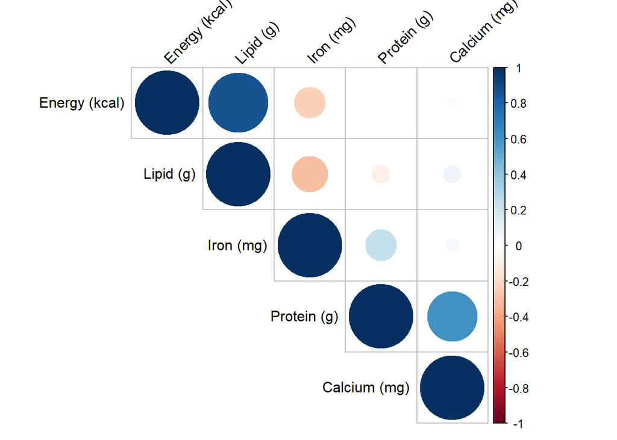

```r
corrplot(M, type="upper", order="hclust", tl.col="black", tl.srt=45)
```

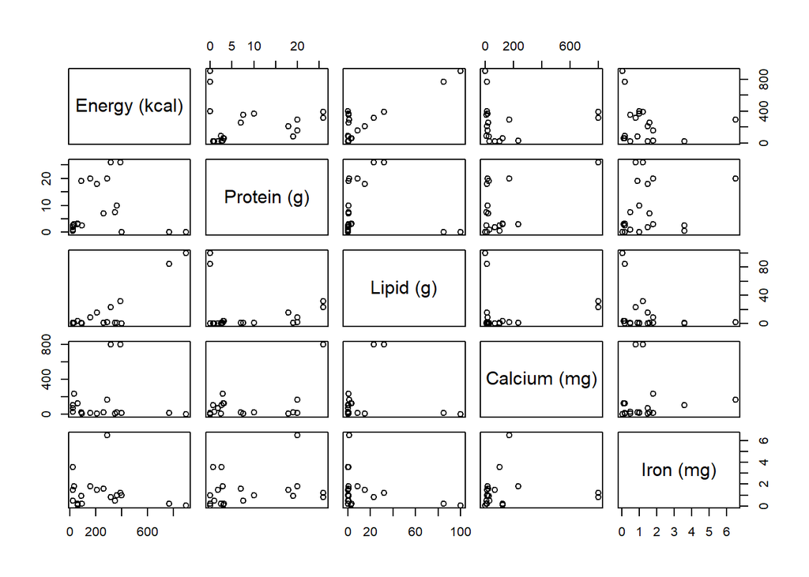

```r
pairs(DataExample_1[,2:6])
```

#### Dfn XII: Individual’s space metric

We denote the individual’s space metric or the metric of one observation as:

$$\mathbf{Q}=\mathbf{I}_{m}$$
or
$$\mathbf{Q}=\begin{pmatrix}
\frac{1}{s^{2}(x^{1})}& 0 & \cdot & \cdot & \cdot & \cdot & \cdot & \cdot & \cdot & 0)\\
0 &\frac{1}{s^{2}(x^{2})} & & & & & & & & \cdot \\
\cdot& & & \cdot & & & & & & \cdot \\
\cdot& & & & & \cdot & & & & \cdot \\
\cdot& & & & & & & \cdot & & \cdot \\
0& \cdot & \cdot & \cdot & \cdot & \cdot & \cdot & \cdot & \cdot & \frac{1}{s^{2}(x^{m})}
\end{pmatrix}_{(m,m)}$$

#### Dfn XII: Characterization of a cluster of individuals

We denote the characterization of a cluster of $k\leq n$ individuals as:
$$K=\left \{ x_{1},x_{2},...,x_{n} \right \}$$

#### Dfn XIv: Center of gravity (of a cluster of observations)

Given a dataset $A_{(n,m)}$ with *n* osbervations and *m* variables, the *center of gravity* of a set of *k* individuals or observations where $k \leq n$, the *center of gravity* is define as:

$$g=\sum_{i=1}^{k}p_{i}x_{i}=\begin{pmatrix}
\overline{x^{1}}\\
\cdot\\
\cdot\\
\cdot\\
\overline{x^{m}}\\
\end{pmatrix}_{(m \times 1)}$$

Note that the center of gravity simply is the **vector of means** of the *m* columns accross the *k* observations in the cluster.

#### Dfn XV: Total Inertia (of a cluster of observations)

Given a dataset $A_{(n,m)}$ with *n* osbervations and *m* variables, the measure of *total inertia* of a set of *k* individuals or observations where $k \leq n$, the *total inertia* is define as:
$$\mathbf{I}g=\sum_{i=1}^{k}p_{i} \left \| x_{i}-g \right \|_{Q}^{2}$$

Note that the *total inertia* simply is the variance (or distance with metric $\mathbf{Q}$) of the *m* columns accross the *k* observations in the cluster. Moreover

- If $p=1 \Rightarrow \mathbf{I} \equiv s^{2}(x^{j}) \forall j \in [1,m]$
- If the data is centered (which simply means that its mean is equal to 0 that means $g=\vec{0}$),then :
- Total Inertia equals the trace of the multiplication of matrixes *V,Q*, or $\mathbf{I}g=\sum_{i=1}^{k}p_{i} \left \| x_{i} \right \|_{Q}^{2}=Tr(VQ)$
- Depending on how is metric is defined:

$$\mathbf{I}g=\left\{\begin{matrix}
\sum_{i=1}^{k}p_{i}s^{2}(x^{j})& if, Q=\mathbf{I}_{P} \\
p & if, Q=(diag(V)^{-1})\end{matrix}\right.$$

## Principal Component Example (wrap up)

To wrap up all the statistics and linear algebra concepts needed for the calculations of **PCA**, lets review the steps. Original example can be found [here](http://www.cs.otago.ac.nz/cosc453/student_tutorials/principal_components.pdf).

### Step 1: Get some dataset

```r
Feature_1<-c(2.5,0.5,2.2,1.9,3.1,2.3,2,1,1.5,1.1)
Feature_2<-c(2.4,0.7,2.9,2.2,3,2.7,1.6,1.1,1.6,0.9)
the_data<-data.frame(cbind(Feature_1,Feature_2))
knitr::kable(the_data, caption = "The dataset (dimensions 10x2)",row.names = TRUE)
```

The dataset (dimensions 10x2)

|  | Feature_1 | Feature_2 |
| --- | --- | --- |
| 1 | 2.5 | 2.4 |
| 2 | 0.5 | 0.7 |
| 3 | 2.2 | 2.9 |
| 4 | 1.9 | 2.2 |
| 5 | 3.1 | 3.0 |
| 6 | 2.3 | 2.7 |
| 7 | 2.0 | 1.6 |
| 8 | 1.0 | 1.1 |
| 9 | 1.5 | 1.6 |
| 10 | 1.1 | 0.9 |

### Step 2: Substract the mean

For this setp you need to calculate the mean of each feature.

```r
the_data_mean<-the_data%>%group_by()%>%summarise(Feature_1_mean=mean(Feature_1),Feature_2_mean=mean(Feature_2))
knitr::kable(the_data_mean, caption = "The mean of each feature",row.names = FALSE)
```

The mean of each feature

| Feature_1_mean | Feature_2_mean |
| --- | --- |
| 1.81 | 1.91 |

Then you substract the mean to each observatio. For presentation purposes next table shows both original dataset and the dataset resulted after this operation

```r
Feature_1_mean<-the_data_mean$Feature_1_mean%>%as.double()
Feature_2_mean<-the_data_mean$Feature_2_mean%>%as.double()

the_data$Feature_1_subs<-the_data$Feature_1-Feature_1_mean
the_data$Feature_2_subs<-the_data$Feature_2-Feature_2_mean

knitr::kable(the_data, caption = "Original dataset plus transformed features (dimension 10x4)",row.names = TRUE)
```

Original dataset plus transformed features (dimension 10x4)

|  | Feature_1 | Feature_2 | Feature_1_subs | Feature_2_subs |
| --- | --- | --- | --- | --- |
| 1 | 2.5 | 2.4 | 0.69 | 0.49 |
| 2 | 0.5 | 0.7 | -1.31 | -1.21 |
| 3 | 2.2 | 2.9 | 0.39 | 0.99 |
| 4 | 1.9 | 2.2 | 0.09 | 0.29 |
| 5 | 3.1 | 3.0 | 1.29 | 1.09 |
| 6 | 2.3 | 2.7 | 0.49 | 0.79 |
| 7 | 2.0 | 1.6 | 0.19 | -0.31 |
| 8 | 1.0 | 1.1 | -0.81 | -0.81 |
| 9 | 1.5 | 1.6 | -0.31 | -0.31 |
| 10 | 1.1 | 0.9 | -0.71 | -1.01 |

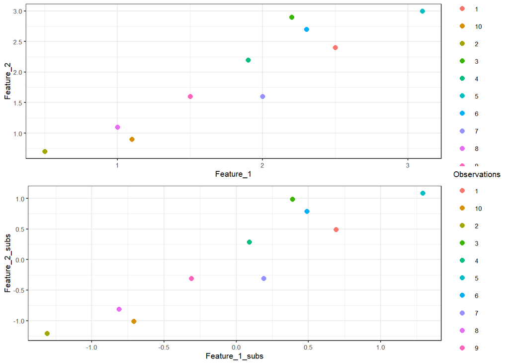

```r
O<-ggplot(the_data,aes(x=Feature_1,y=Feature_2))+geom_point(mapping = aes(color=row.names(the_data)),size = 2)+labs(color = "Observations")+ theme_bw(base_size = 8)
A<-ggplot(the_data,aes(x=Feature_1_subs,y=Feature_2_subs))+geom_point(mapping = aes(color=row.names(the_data)),size = 2)+labs(color = "Observations")+ theme_bw(base_size = 8)
grid.arrange(O,A,ncol=1)
```

Note that substracting the mean does nothing to the pattern of how the data is *spread*, however it does modifies the spam range for each of the axis.

### Step 3: Calculate the covariance matrix

```r
aux<-the_data
range.names = colnames(aux[,3:4])
names(aux) = range.names
covmatrix = matrix(c(cov(aux[,3:4])),nrow=2, ncol=2)
dimnames(covmatrix) = list(range.names, range.names)

#Covariance matrix
knitr::kable(covmatrix, caption = "Variance and covariance Matrix",row.names = TRUE)
```

Variance and covariance Matrix

|  | Feature_1_subs | Feature_2_subs |
| --- | --- | --- |
| Feature_1_subs | 0.6165556 | 0.6154444 |
| Feature_2_subs | 0.6154444 | 0.7165556 |

### Step 4: Calculate the eigenvectors and eigenvalues of the covariance matrix

##### 4.1 Eigenvalues

$$det(\begin{pmatrix}
s^{2}(x_{1}) & s(x_{1},x_{2})\\
s(x_{2},x_{1}) & s^{2}(x_{2})
\end{pmatrix} - \lambda \mathbf{I}_{(2 \times 2)})=0$$

Solving the resulting equation for $\lambda$ will result in the *eigenvalues* associated to the *covariance matrix*.

##### 4.2 Eigenvectors

In general, given a *square matrix* $A_{(n \times n)}$ and its associated *eigenvalues* the *eigenvectors* $v$ associated to them are such that meet the following criteria:

$$A_{(n \times n)}v_{(n \times 1)}=\lambda v_{(n \times 1)}$$
In the context of our example after solving 4.1, we get

$$eigenvalues=\begin{pmatrix}
1.28402771\\
.0490833989
\end{pmatrix}$$

And after solving for 4.2, we get

$$\textit{eigenvectors (not unit)}=\begin{pmatrix}
0.922053 & -1.08454\\
1 & 1
\end{pmatrix}$$

For **PCA** we need **unit vectors** that are the vectors divided by its *euclidean magnitude*. So in our case:

$$\textit{eigenvectors (not unit)}_{1}=\begin{pmatrix}
0.922053 \\
1
\end{pmatrix}$$
And its *euclidean magnitude*: $\sqrt{{0.922053}^{2}+{1}^{2}}=1.360214$. And so the first unit eigenvector associated with the first eigenvalue $1.28402771$, is constructed as follows:

$$\frac{1}{1.360214} \times \textit{eigenvectors (not unit)}_{1}=\frac{1}{1.360214} \times \begin{pmatrix}
0.922053 \\
1
\end{pmatrix}=\begin{pmatrix}
0.6778735 \\
0.7351784
\end{pmatrix}$$

For the second not unit eigenvecotr we follow exactly the same procedure.

$$\textit{eigenvectors (not unit)}_{2}=\begin{pmatrix}
-1.08454 \\
1
\end{pmatrix}$$
And its *euclidean magnitude*: $\sqrt{{ -1.08454}^{2}+{1}^{2}}=1.475204$.

And so the second unit eigenvector associated with the first eigenvalue $.0490833989$, is constructed as follows:

$$\frac{1}{1.475204} \times \textit{eigenvectors (not unit)}_{2}=\frac{1}{1.475204} \times \begin{pmatrix}
-1.08454 \\
1
\end{pmatrix}=\begin{pmatrix}
-0.7351797 \\
0.6778723
\end{pmatrix}$$

Summarizing the results we have:

$$eigenvectors=\begin{pmatrix}
0.6778735 & -0.7351797\\
0.7351784 & 0.6778723
\end{pmatrix}$$

What does this unit eigenvector means, lets look to the following graph:

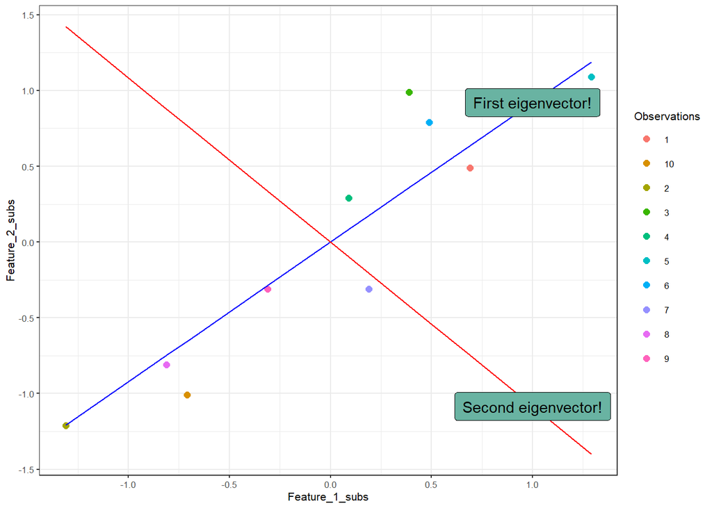

```r
A<-ggplot(the_data,aes(x=Feature_1_subs,y=Feature_2_subs))+geom_point(mapping = aes(color=row.names(the_data)),size = 2)+labs(color = "Observations")+ theme_bw(base_size = 8)
B<-A+geom_line(mapping = aes(y=(0.6778735/0.7351784)*Feature_1_subs),color="blue")+labs(line="First component") + geom_label(
    label="First eigenvector!",
    x=1,
    y=(0.6778735/0.7351784)*1,
    label.padding = unit(0.4, "lines"), # Rectangle size around label
    label.size = 0.2,
    color = "black",
    fill="#69b3a2"
  )
B+geom_line(mapping = aes(y=(−0.7351797/0.6778723)*Feature_1_subs),color="red") + geom_label(
    label="Second eigenvector!",
    x=1,
    y=(−0.7351797/0.6778723)*1,
    label.padding = unit(0.4, "lines"), # Rectangle size around label
    label.size = 0.2,
    color = "black",
    fill="#69b3a2"
  )
```

For a nice video to watch examples on the use of eigenstuff please see [here.](https://www.youtube.com/watch?v=i8FukKfMKCI&t=1235s)

### Step 5: Choosing components and forming a feature vector

Once eigenvectors are found from the covariance matrix, the next step is to order them by eigenvalue, highest to lowest.This gives you the components in order of significance. Now, you can decide to ignore the components of lesser significance. You do lose some information, but if the eigenvalues are small, you don’t lose much. If you leave out some components, the final data set will have less dimensions than the original

Precisely, if you originally have $n$ dimensions in your original dataset, and so you calculate $n$ eigenvectors and their associated eigenvalues, and then you choose only the first $p$ eigenvectors, then the final data set has only $p$ dimensions.

#### Feature vector

A *feature vector* is a matrix of vectors, such that each of the vector forming the matrix is the eigenvector associated to the eigenvalues from the covariance matrix of the original dataset.
$$FeatureVector_{(p \times p)}=(\vec{eig_{1}},\vec{eig_{2}},\vec{eig_{3}},...,\vec{eig_{p}})$$

Given our example dataset, we have the following *featurevector*

$$\begin{pmatrix}
0.6778735 & -0.7351797\\
0.7351784 & 0.6778723
\end{pmatrix}$$

In the following [link](https://github.com/EduardoHidalgoGarcia/EduardoHidalgoWebsite/blob/master/Classes/MultivariateAnalysis/PCA_Example.xlsx) the auxiliar excel document used during the session is available.

### Step 6: Deriving the new dataset

This the final step in PCA,once we have chosen the components (eigenvectors) that we wish to keep in our data and formed a feature vector, we simply take the *transpose of that vector* and multiply it on the left of the original dataset, transposed.

$$FinalData_{(p \times n)}=RowFeatureVector_{(p \times p)} \times RowDataAdjust_{(p \times n)}$$

where $RowFeatureVector$ is the *matrix with the eigenvectors in the columns transposed* so that the eigenvectors are now in the rows, with the most significant eigenvector at the top, and $RowDataAdjust$ is the *mean-adjusted data transposed*, ie. the data items are in each column, with each row holding a separate dimension. $FinalData$ is the final dataset, with **data items in columns**, and **dimensions along rows** (so it has a transpose structure when compared with the original dataset).

## Principal Component Example (exercise)